# BRAIN STROKE PREDICTION

Brain Stroke:

A stroke is a medical condition in which poor blood flow to the brain causes cell death. According to the World Health Organization (WHO) stroke is the 2nd leading cause of death globally, responsible for approximately 11% of total deaths.

Dataset Link: https://www.kaggle.com/datasets/fedesoriano/stroke-prediction-dataset

```r
dataset<-read.csv("C:/Users/Jerrick/Downloads/R Project/full_filled_stroke_data (1).csv")
head(dataset)
```

```r
library(ggplot2)
stroke_df = read.csv("healthcare-dataset-stroke-data.csv")
stroke_df = subset(stroke_df, select = -c(id))
head(stroke_df)
```

[output not shown]

```r
str(dataset)
```

```
## 'data.frame':    201 obs. of  11 variables:
##  $ gender           : chr  "Female" "Female" "Male" "Male" ...
##  $ age              : num  61 59 78 57 58 59 63 75 76 78 ...
##  $ hypertension     : int  0 0 0 0 0 0 0 0 0 1 ...
##  $ heart_disease    : int  0 0 1 1 0 0 0 1 0 0 ...
##  $ ever_married     : chr  "Yes" "Yes" "Yes" "No" ...
##  $ work_type        : chr  "Self-employed" "Private" "Private" "Govt_job" ...
##  $ Residence_type   : chr  "Rural" "Rural" "Urban" "Urban" ...
##  $ avg_glucose_level: num  202.2 76.2 219.8 217.1 189.8 ...
##  $ bmi              : num  31.6 30.2 30.7 33.8 31.4 ...
##  $ smoking_status   : chr  "never smoked" "Unknown" "Unknown" "Unknown" ...
##  $ stroke           : int  1 1 1 1 1 1 1 1 1 1 ...
```

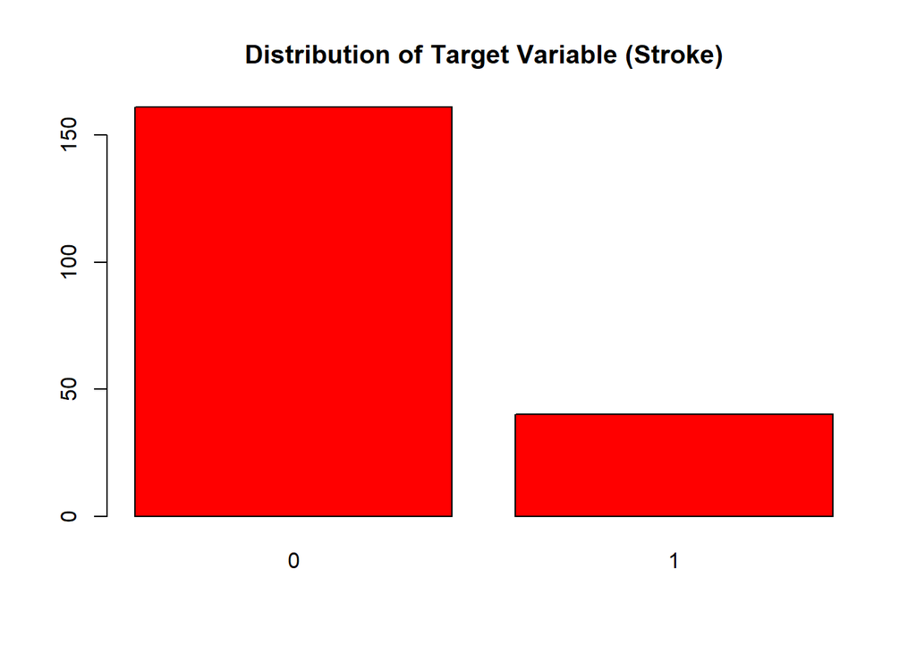

```r
df<-table(dataset$stroke)
barplot(df,main='Distribution of Target Variable (Stroke)',col='Red')
```

So from the plot, we can see that the number of observations of 0 is greater than the number of observations 1. From this we can see that the dataset is imbalanced.

```r
# changing the variables to categorical variables and numerical variables
stroke_df$gender <- as.factor(stroke_df$gender)
stroke_df$hypertension <- as.factor(stroke_df$hypertension)
stroke_df$heart_disease <- as.factor(stroke_df$heart_disease)
stroke_df$ever_married <- as.factor(stroke_df$ever_married)
stroke_df$bmi <- as.numeric(stroke_df$bmi)
stroke_df$stroke<- as.factor(stroke_df$stroke)
str(stroke_df)
```

```
## 'data.frame':    5110 obs. of  11 variables:
##  $ gender           : Factor w/ 3 levels "Female","Male",..: 2 1 2 1 1 2 2 1 1 1 ...
##  $ age              : num  67 61 80 49 79 81 74 69 59 78 ...
##  $ hypertension     : Factor w/ 2 levels "0","1": 1 1 1 1 2 1 2 1 1 1 ...
##  $ heart_disease    : Factor w/ 2 levels "0","1": 2 1 2 1 1 1 2 1 1 1 ...
##  $ ever_married     : Factor w/ 2 levels "No","Yes": 2 2 2 2 2 2 2 1 2 2 ...
##  $ work_type        : chr  "Private" "Self-employed" "Private" "Private" ...
##  $ Residence_type   : chr  "Urban" "Rural" "Rural" "Urban" ...
##  $ avg_glucose_level: num  229 202 106 171 174 ...
##  $ bmi              : num  36.6 NA 32.5 34.4 24 29 27.4 22.8 NA 24.2 ...
##  $ smoking_status   : chr  "formerly smoked" "never smoked" "never smoked" "smokes" ...
##  $ stroke           : Factor w/ 2 levels "0","1": 2 2 2 2 2 2 2 2 2 2 ...
```

```r
# Finding if there are any NA's in the dataset
paste("The NA's in the dataset is:",sum(is.na(stroke_df)))
```

```
## [1] "The NA's in the dataset is: 201"
```

```r
summary(stroke_df)
```

```
##     gender          age        hypertension heart_disease ever_married
##  Female:2994   Min.   : 0.08   0:4612       0:4834        No :1757
##  Male  :2115   1st Qu.:25.00   1: 498       1: 276        Yes:3353
##  Other :   1   Median :45.00
##                Mean   :43.23
##                3rd Qu.:61.00
##                Max.   :82.00
##
##   work_type         Residence_type     avg_glucose_level      bmi
##  Length:5110        Length:5110        Min.   : 55.12    Min.   :10.30
##  Class :character   Class :character   1st Qu.: 77.25    1st Qu.:23.50
##  Mode  :character   Mode  :character   Median : 91.89    Median :28.10
##                                        Mean   :106.15    Mean   :28.89
##                                        3rd Qu.:114.09    3rd Qu.:33.10
##                                        Max.   :271.74    Max.   :97.60
##                                                          NA's   :201
##  smoking_status     stroke
##  Length:5110        0:4861
##  Class :character   1: 249
##  Mode  :character
##
##
##
##
```

```r
# There are 201 NA's in BMI. Replacing those variables with mean of BMI
stroke_df$bmi[is.na(stroke_df$bmi)] <- mean(stroke_df$bmi,na.rm = TRUE)
# Finding if there are any NA's after imputation of null values
paste("The NA's in the dataset is:",sum(is.na(stroke_df)))
```

```
## [1] "The NA's in the dataset is: 0"
```

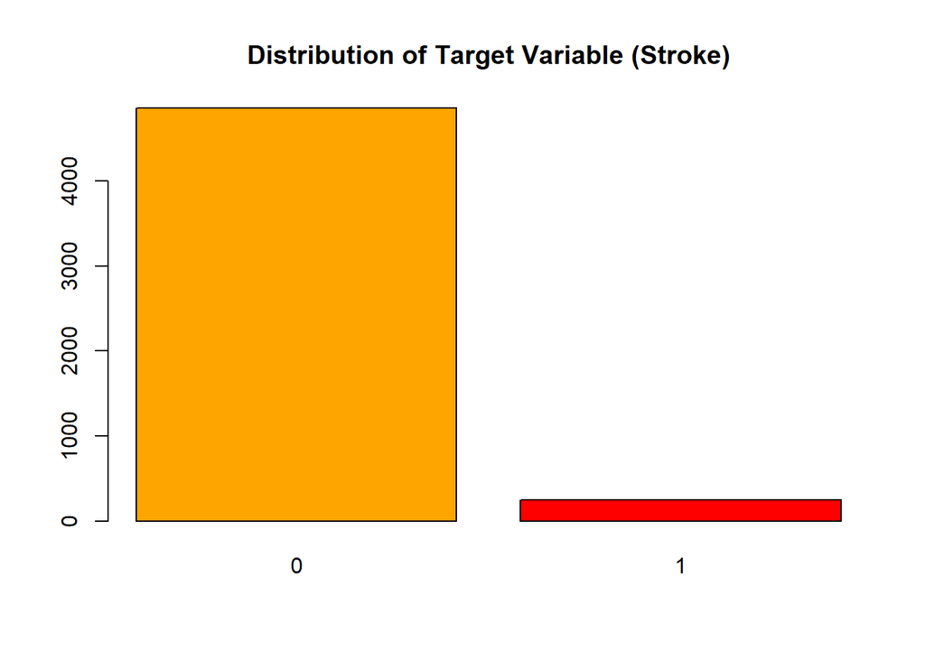

```r
df<-table(stroke_df$stroke)

barplot(df,main='Distribution of Target Variable (Stroke)',col=c('orange','red'))
```

So from the plot, we can see that the number of observations of 0 is greater than the number of observations 1. From this we can see that the dataset is imbalanced.

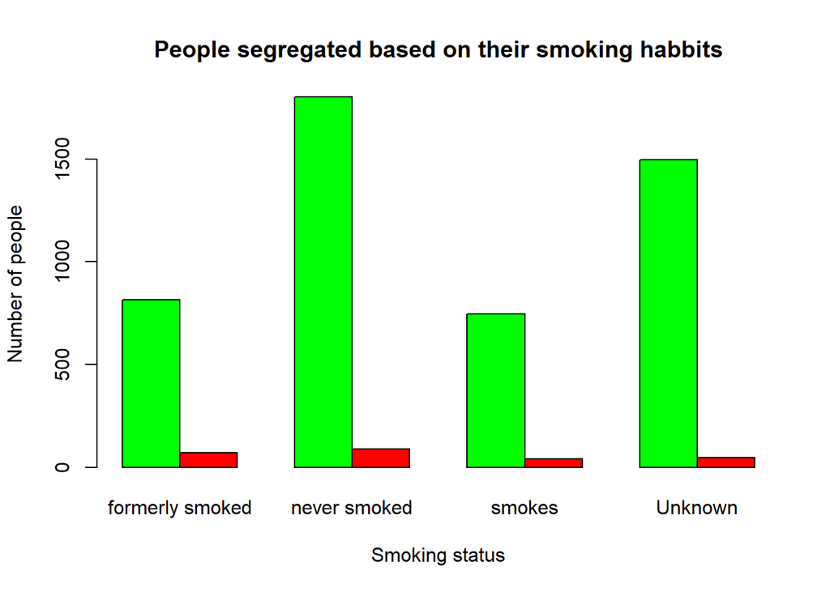

```r
dat=table(stroke_df$stroke,stroke_df$smoking_status)
barplot(dat,
main = "People segregated based on their smoking habbits",
xlab = "Smoking status",
ylab = "Number of people",
col = c("Green","red"),
beside = TRUE
)
```

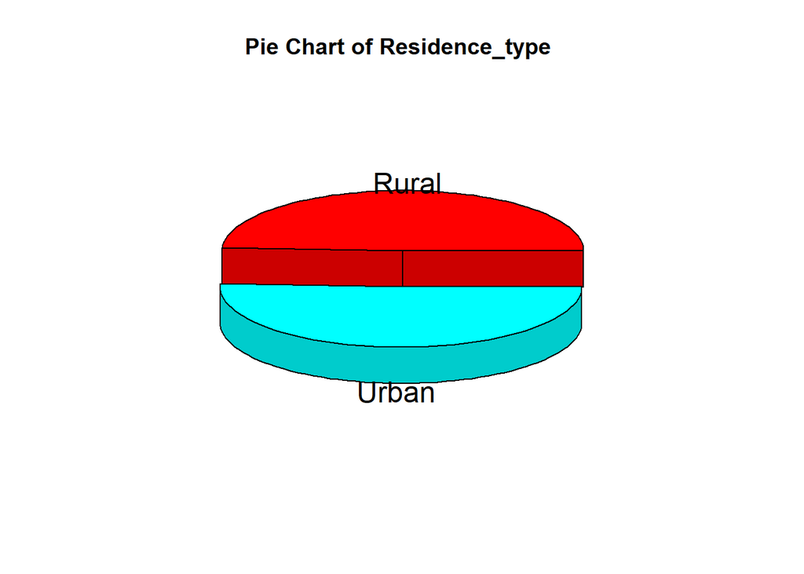

```r
#Pie Plot for Rural VS URBAN

library(plotrix)
df2<-table(stroke_df$Residence_type)
lab<-c('Rural','Urban')
pie3D(df2,explode=0.2,main="Pie Chart of Residence_type ",labels = lab)
```

```r
# Compare residence type with stroke
tab1 = table(stroke_df$Residence_type, stroke_df$stroke)
names(dimnames(tab1))<- c("Work Type", "Stroke")
tab1
```

```
##          Stroke
## Work Type    0    1
##     Rural 2400  114
##     Urban 2461  135
```

So we can see that people in Rural area with no effect of brain stroke is 2400 and 2461 in Urban Rural area people with brain stroke is 114 and 135 in Urban.

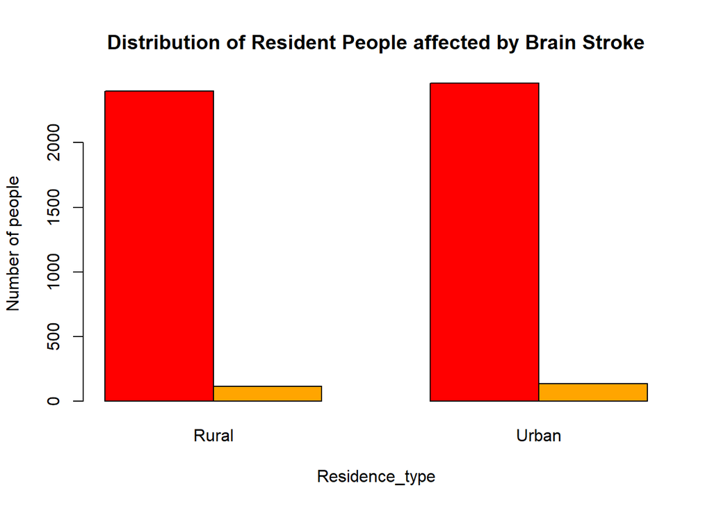

```r
resi=table(stroke_df$stroke,stroke_df$Residence_type)
barplot(resi,
main = "Distribution of Resident People affected by Brain Stroke",
xlab = "Residence_type",
ylab = "Number of people",
col = c("Red","Orange"),
beside = TRUE
)
```

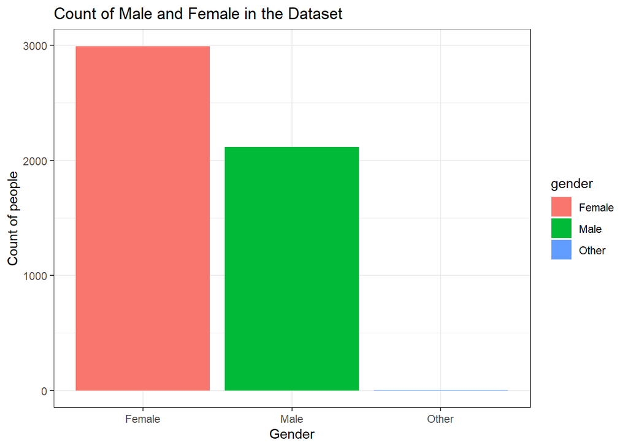

```r
# Count of Males and Females in the Dataset
ggplot(stroke_df, aes(x=gender,fill=gender))+geom_bar()+ggtitle("Count of Male and Female in the Dataset")+ theme_bw() +
  theme()+ xlab("Gender") + ylab("Count of people")
```

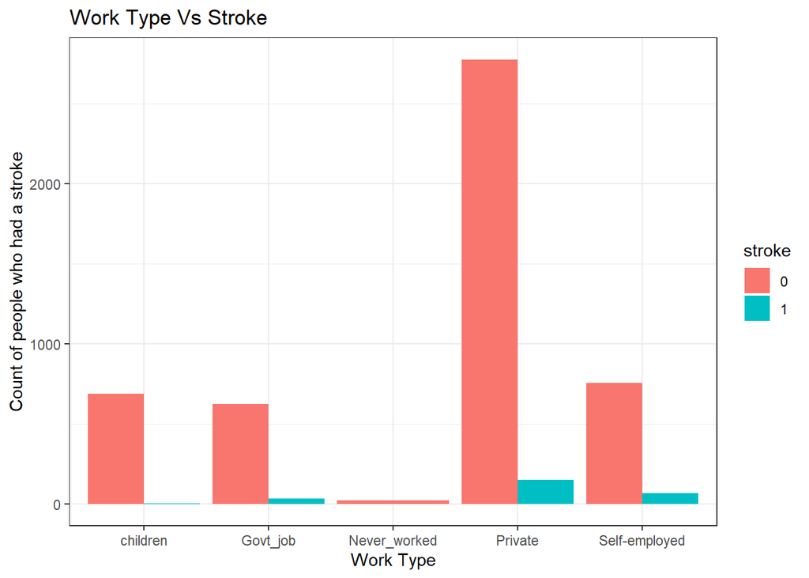

```r
# Seeing if work type affects people
ggplot(stroke_df,aes(x=work_type, fill=stroke))+geom_bar(position = "dodge")+ggtitle("Work Type Vs Stroke")+ theme_bw() +
  theme()+ xlab("Work Type") + ylab("Count of people who had a stroke")
```

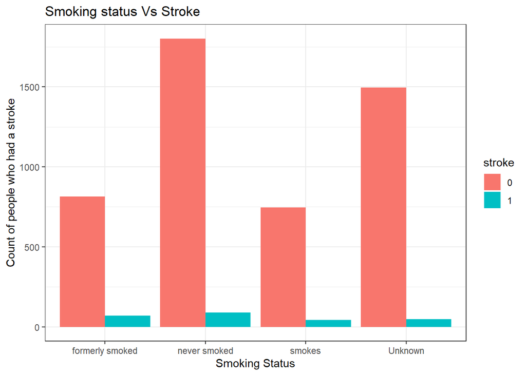

```r
# Seeing if Smoking status causes stroke
ggplot(stroke_df,aes(x=smoking_status, fill=stroke))+geom_bar(position = "dodge")+ggtitle("Smoking status Vs Stroke")+ theme_bw() + theme()+ xlab("Smoking Status") + ylab("Count of people who had a stroke")
```